# Risk Factor Analysis

## Outcome Variable

**Outcome Variable:** stunted

## Predictor Variables

**Intervention Variable:** birthwt

**Adjustment Set:**

- arm
- sex
- W_mage
- meducyrs
- feducyrs
- W_mhtcm
- vagbrth
- single
- brthmon
- W_parity
- delta_W_mage
- delta_meducyrs
- delta_feducyrs
- delta_W_mhtcm
- delta_vagbrth
- delta_single
- delta_brthmon
- delta_W_parity

## Stratifying Variables

The analysis was stratified on these variable(s):

- agecat
- studyid
- country

## Data Summary

| agecat | studyid | country | birthwt | stunted | n_cell | n |
| --- | --- | --- | --- | --- | --- | --- |
| Birth | ki0047075b-MAL-ED | BANGLADESH | >=0 | 0 | 34 | 257 |
| Birth | ki0047075b-MAL-ED | BANGLADESH | >=0 | 1 | 0 | 257 |
| Birth | ki0047075b-MAL-ED | BANGLADESH | <-3 | 0 | 0 | 257 |
| Birth | ki0047075b-MAL-ED | BANGLADESH | <-3 | 1 | 7 | 257 |
| Birth | ki0047075b-MAL-ED | BANGLADESH | [-3–2) | 0 | 16 | 257 |
| Birth | ki0047075b-MAL-ED | BANGLADESH | [-3–2) | 1 | 22 | 257 |
| Birth | ki0047075b-MAL-ED | BANGLADESH | [-2–1) | 0 | 82 | 257 |
| Birth | ki0047075b-MAL-ED | BANGLADESH | [-2–1) | 1 | 14 | 257 |
| Birth | ki0047075b-MAL-ED | BANGLADESH | [-1-0) | 0 | 78 | 257 |
| Birth | ki0047075b-MAL-ED | BANGLADESH | [-1-0) | 1 | 4 | 257 |
| 6 months | ki0047075b-MAL-ED | BANGLADESH | >=0 | 0 | 32 | 234 |
| 6 months | ki0047075b-MAL-ED | BANGLADESH | >=0 | 1 | 1 | 234 |
| 6 months | ki0047075b-MAL-ED | BANGLADESH | <-3 | 0 | 2 | 234 |
| 6 months | ki0047075b-MAL-ED | BANGLADESH | <-3 | 1 | 2 | 234 |
| 6 months | ki0047075b-MAL-ED | BANGLADESH | [-3–2) | 0 | 19 | 234 |
| 6 months | ki0047075b-MAL-ED | BANGLADESH | [-3–2) | 1 | 15 | 234 |
| 6 months | ki0047075b-MAL-ED | BANGLADESH | [-2–1) | 0 | 70 | 234 |
| 6 months | ki0047075b-MAL-ED | BANGLADESH | [-2–1) | 1 | 16 | 234 |
| 6 months | ki0047075b-MAL-ED | BANGLADESH | [-1-0) | 0 | 68 | 234 |
| 6 months | ki0047075b-MAL-ED | BANGLADESH | [-1-0) | 1 | 9 | 234 |
| 24 months | ki0047075b-MAL-ED | BANGLADESH | >=0 | 0 | 27 | 207 |
| 24 months | ki0047075b-MAL-ED | BANGLADESH | >=0 | 1 | 4 | 207 |
| 24 months | ki0047075b-MAL-ED | BANGLADESH | <-3 | 0 | 0 | 207 |
| 24 months | ki0047075b-MAL-ED | BANGLADESH | <-3 | 1 | 4 | 207 |
| 24 months | ki0047075b-MAL-ED | BANGLADESH | [-3–2) | 0 | 10 | 207 |
| 24 months | ki0047075b-MAL-ED | BANGLADESH | [-3–2) | 1 | 19 | 207 |
| 24 months | ki0047075b-MAL-ED | BANGLADESH | [-2–1) | 0 | 38 | 207 |
| 24 months | ki0047075b-MAL-ED | BANGLADESH | [-2–1) | 1 | 35 | 207 |
| 24 months | ki0047075b-MAL-ED | BANGLADESH | [-1-0) | 0 | 38 | 207 |
| 24 months | ki0047075b-MAL-ED | BANGLADESH | [-1-0) | 1 | 32 | 207 |

[output cut: 634 more lines]

The following strata were considered:

- agecat: 24 months, studyid: ki0047075b-MAL-ED, country: BANGLADESH
- agecat: 24 months, studyid: ki0047075b-MAL-ED, country: BRAZIL
- agecat: 24 months, studyid: ki0047075b-MAL-ED, country: INDIA
- agecat: 24 months, studyid: ki0047075b-MAL-ED, country: NEPAL
- agecat: 24 months, studyid: ki0047075b-MAL-ED, country: PERU
- agecat: 24 months, studyid: ki0047075b-MAL-ED, country: SOUTH AFRICA
- agecat: 24 months, studyid: ki0047075b-MAL-ED, country: TANZANIA, UNITED REPUBLIC OF
- agecat: 24 months, studyid: ki1000108-CMC-V-BCS-2002, country: INDIA
- agecat: 24 months, studyid: ki1000108-IRC, country: INDIA
- agecat: 24 months, studyid: ki1017093-NIH-Birth, country: BANGLADESH
- agecat: 24 months, studyid: ki1017093b-PROVIDE, country: BANGLADESH
- agecat: 24 months, studyid: ki1017093c-NIH-Crypto, country: BANGLADESH
- agecat: 24 months, studyid: ki1066203-TanzaniaChild2, country: TANZANIA, UNITED REPUBLIC OF
- agecat: 24 months, studyid: ki1101329-Keneba, country: GAMBIA
- agecat: 24 months, studyid: ki1114097-CMIN, country: PERU
- agecat: 24 months, studyid: ki1114097-CONTENT, country: PERU
- agecat: 24 months, studyid: ki1119695-PROBIT, country: BELARUS
- agecat: 24 months, studyid: ki1126311-ZVITAMBO, country: ZIMBABWE
- agecat: 24 months, studyid: ki1135781-COHORTS, country: GUATEMALA
- agecat: 24 months, studyid: ki1135781-COHORTS, country: INDIA
- agecat: 24 months, studyid: ki1135781-COHORTS, country: PHILIPPINES
- agecat: 24 months, studyid: kiGH5241-JiVitA-3, country: BANGLADESH
- agecat: 24 months, studyid: kiGH5241-JiVitA-4, country: BANGLADESH
- agecat: 6 months, studyid: ki0047075b-MAL-ED, country: BANGLADESH
- agecat: 6 months, studyid: ki0047075b-MAL-ED, country: BRAZIL
- agecat: 6 months, studyid: ki0047075b-MAL-ED, country: INDIA
- agecat: 6 months, studyid: ki0047075b-MAL-ED, country: NEPAL
- agecat: 6 months, studyid: ki0047075b-MAL-ED, country: PERU
- agecat: 6 months, studyid: ki0047075b-MAL-ED, country: SOUTH AFRICA
- agecat: 6 months, studyid: ki0047075b-MAL-ED, country: TANZANIA, UNITED REPUBLIC OF
- agecat: 6 months, studyid: ki1000108-CMC-V-BCS-2002, country: INDIA
- agecat: 6 months, studyid: ki1000108-IRC, country: INDIA
- agecat: 6 months, studyid: ki1000109-EE, country: PAKISTAN
- agecat: 6 months, studyid: ki1000109-ResPak, country: PAKISTAN
- agecat: 6 months, studyid: ki1000304b-SAS-CompFeed, country: INDIA
- agecat: 6 months, studyid: ki1017093-NIH-Birth, country: BANGLADESH
- agecat: 6 months, studyid: ki1017093b-PROVIDE, country: BANGLADESH
- agecat: 6 months, studyid: ki1017093c-NIH-Crypto, country: BANGLADESH
- agecat: 6 months, studyid: ki1066203-TanzaniaChild2, country: TANZANIA, UNITED REPUBLIC OF
- agecat: 6 months, studyid: ki1101329-Keneba, country: GAMBIA
- agecat: 6 months, studyid: ki1114097-CMIN, country: BRAZIL
- agecat: 6 months, studyid: ki1114097-CMIN, country: PERU
- agecat: 6 months, studyid: ki1114097-CONTENT, country: PERU
- agecat: 6 months, studyid: ki1119695-PROBIT, country: BELARUS
- agecat: 6 months, studyid: ki1126311-ZVITAMBO, country: ZIMBABWE
- agecat: 6 months, studyid: ki1135781-COHORTS, country: GUATEMALA
- agecat: 6 months, studyid: ki1135781-COHORTS, country: INDIA
- agecat: 6 months, studyid: ki1135781-COHORTS, country: PHILIPPINES
- agecat: 6 months, studyid: kiGH5241-JiVitA-3, country: BANGLADESH
- agecat: 6 months, studyid: kiGH5241-JiVitA-4, country: BANGLADESH
- agecat: Birth, studyid: ki0047075b-MAL-ED, country: BANGLADESH
- agecat: Birth, studyid: ki0047075b-MAL-ED, country: BRAZIL
- agecat: Birth, studyid: ki0047075b-MAL-ED, country: INDIA
- agecat: Birth, studyid: ki0047075b-MAL-ED, country: NEPAL
- agecat: Birth, studyid: ki0047075b-MAL-ED, country: PERU
- agecat: Birth, studyid: ki0047075b-MAL-ED, country: SOUTH AFRICA
- agecat: Birth, studyid: ki0047075b-MAL-ED, country: TANZANIA, UNITED REPUBLIC OF
- agecat: Birth, studyid: ki1000108-CMC-V-BCS-2002, country: INDIA
- agecat: Birth, studyid: ki1000108-IRC, country: INDIA
- agecat: Birth, studyid: ki1000109-EE, country: PAKISTAN
- agecat: Birth, studyid: ki1000109-ResPak, country: PAKISTAN
- agecat: Birth, studyid: ki1000304b-SAS-CompFeed, country: INDIA
- agecat: Birth, studyid: ki1017093-NIH-Birth, country: BANGLADESH
- agecat: Birth, studyid: ki1017093c-NIH-Crypto, country: BANGLADESH
- agecat: Birth, studyid: ki1101329-Keneba, country: GAMBIA
- agecat: Birth, studyid: ki1114097-CMIN, country: BANGLADESH
- agecat: Birth, studyid: ki1114097-CMIN, country: BRAZIL
- agecat: Birth, studyid: ki1114097-CMIN, country: PERU
- agecat: Birth, studyid: ki1114097-CONTENT, country: PERU
- agecat: Birth, studyid: ki1119695-PROBIT, country: BELARUS
- agecat: Birth, studyid: ki1126311-ZVITAMBO, country: ZIMBABWE
- agecat: Birth, studyid: ki1135781-COHORTS, country: GUATEMALA
- agecat: Birth, studyid: ki1135781-COHORTS, country: INDIA
- agecat: Birth, studyid: ki1135781-COHORTS, country: PHILIPPINES
- agecat: Birth, studyid: kiGH5241-JiVitA-3, country: BANGLADESH
- agecat: Birth, studyid: kiGH5241-JiVitA-4, country: BANGLADESH

### Dropped Strata

Some strata were dropped due to rare outcomes:

- agecat: Birth, studyid: ki0047075b-MAL-ED, country: BANGLADESH
- agecat: 6 months, studyid: ki0047075b-MAL-ED, country: BANGLADESH
- agecat: 24 months, studyid: ki0047075b-MAL-ED, country: BANGLADESH
- agecat: Birth, studyid: ki0047075b-MAL-ED, country: BRAZIL
- agecat: 6 months, studyid: ki0047075b-MAL-ED, country: BRAZIL
- agecat: 24 months, studyid: ki0047075b-MAL-ED, country: BRAZIL
- agecat: Birth, studyid: ki0047075b-MAL-ED, country: INDIA
- agecat: 6 months, studyid: ki0047075b-MAL-ED, country: INDIA
- agecat: 24 months, studyid: ki0047075b-MAL-ED, country: INDIA
- agecat: Birth, studyid: ki0047075b-MAL-ED, country: NEPAL
- agecat: 6 months, studyid: ki0047075b-MAL-ED, country: NEPAL
- agecat: 24 months, studyid: ki0047075b-MAL-ED, country: NEPAL
- agecat: Birth, studyid: ki0047075b-MAL-ED, country: PERU
- agecat: 6 months, studyid: ki0047075b-MAL-ED, country: PERU
- agecat: 24 months, studyid: ki0047075b-MAL-ED, country: PERU
- agecat: Birth, studyid: ki0047075b-MAL-ED, country: SOUTH AFRICA
- agecat: 6 months, studyid: ki0047075b-MAL-ED, country: SOUTH AFRICA
- agecat: 24 months, studyid: ki0047075b-MAL-ED, country: SOUTH AFRICA
- agecat: Birth, studyid: ki0047075b-MAL-ED, country: TANZANIA, UNITED REPUBLIC OF
- agecat: 6 months, studyid: ki0047075b-MAL-ED, country: TANZANIA, UNITED REPUBLIC OF
- agecat: 24 months, studyid: ki0047075b-MAL-ED, country: TANZANIA, UNITED REPUBLIC OF
- agecat: 6 months, studyid: ki1000108-CMC-V-BCS-2002, country: INDIA
- agecat: 24 months, studyid: ki1000108-CMC-V-BCS-2002, country: INDIA
- agecat: Birth, studyid: ki1000108-CMC-V-BCS-2002, country: INDIA
- agecat: 24 months, studyid: ki1000108-IRC, country: INDIA
- agecat: Birth, studyid: ki1000108-IRC, country: INDIA
- agecat: Birth, studyid: ki1000109-EE, country: PAKISTAN
- agecat: Birth, studyid: ki1000109-ResPak, country: PAKISTAN
- agecat: 6 months, studyid: ki1000109-ResPak, country: PAKISTAN
- agecat: Birth, studyid: ki1000304b-SAS-CompFeed, country: INDIA
- agecat: Birth, studyid: ki1017093-NIH-Birth, country: BANGLADESH
- agecat: 6 months, studyid: ki1017093-NIH-Birth, country: BANGLADESH
- agecat: 24 months, studyid: ki1017093-NIH-Birth, country: BANGLADESH
- agecat: 6 months, studyid: ki1017093b-PROVIDE, country: BANGLADESH
- agecat: 24 months, studyid: ki1017093b-PROVIDE, country: BANGLADESH
- agecat: Birth, studyid: ki1017093c-NIH-Crypto, country: BANGLADESH
- agecat: 24 months, studyid: ki1017093c-NIH-Crypto, country: BANGLADESH
- agecat: 24 months, studyid: ki1066203-TanzaniaChild2, country: TANZANIA, UNITED REPUBLIC OF
- agecat: Birth, studyid: ki1101329-Keneba, country: GAMBIA
- agecat: Birth, studyid: ki1114097-CMIN, country: BANGLADESH
- agecat: Birth, studyid: ki1114097-CMIN, country: BRAZIL
- agecat: 6 months, studyid: ki1114097-CMIN, country: BRAZIL
- agecat: Birth, studyid: ki1114097-CMIN, country: PERU
- agecat: 6 months, studyid: ki1114097-CMIN, country: PERU
- agecat: 24 months, studyid: ki1114097-CMIN, country: PERU
- agecat: Birth, studyid: ki1114097-CONTENT, country: PERU
- agecat: 6 months, studyid: ki1114097-CONTENT, country: PERU
- agecat: 24 months, studyid: ki1114097-CONTENT, country: PERU
- agecat: Birth, studyid: ki1119695-PROBIT, country: BELARUS
- agecat: 24 months, studyid: ki1126311-ZVITAMBO, country: ZIMBABWE
- agecat: Birth, studyid: ki1135781-COHORTS, country: GUATEMALA
- agecat: 6 months, studyid: ki1135781-COHORTS, country: GUATEMALA
- agecat: 24 months, studyid: ki1135781-COHORTS, country: GUATEMALA
- agecat: Birth, studyid: ki1135781-COHORTS, country: PHILIPPINES
- agecat: Birth, studyid: kiGH5241-JiVitA-3, country: BANGLADESH
- agecat: Birth, studyid: kiGH5241-JiVitA-4, country: BANGLADESH

## Methods Detail

We’re interested in the causal parameters $E[Y_a]$ for all values of $a \in \mathcal{A}$. These parameters represent the mean outcome if, possibly contrary to fact, we intervened to set all units to have $A=a$. Under the randomization and positivity assumptions, these are identified by the statistical parameters $\psi_a=E_W[E_{Y|A,W}(Y|A=a,W)]$. In addition, we’re interested in the mean of $Y$, $E[Y]$ under no intervention (the observed mean). We will estimate these parameters by using SuperLearner to fit the relevant likelihood factors – $E_{Y|A,W}(Y|A=a,W)$ and $p(A=a|W)$, and then updating our likelihood fit using a joint TMLE.

For unadjusted analyses ($W=\{\}$), initial likelihoods were estimated using Lrnr_glm to estimate the simple $E(Y|A)$ and Lrnr_mean to estimate $p(A)$. For adjusted analyses, a small library containing Lrnr_glmnet, Lrnr_xgboost, and Lrnr_mean was used.

Having estimated these parameters, we will then use the delta method to estimate relative risks and attributable risks relative to a prespecified baseline level of $A$.

[output not shown]

[output not shown]

# Results Detail

## Results Plots

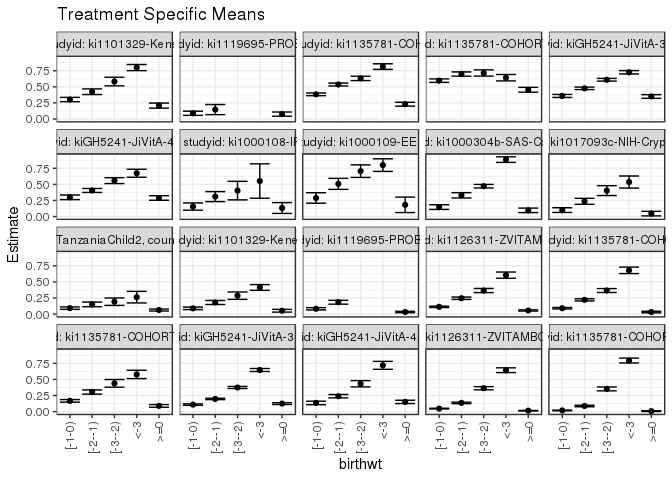

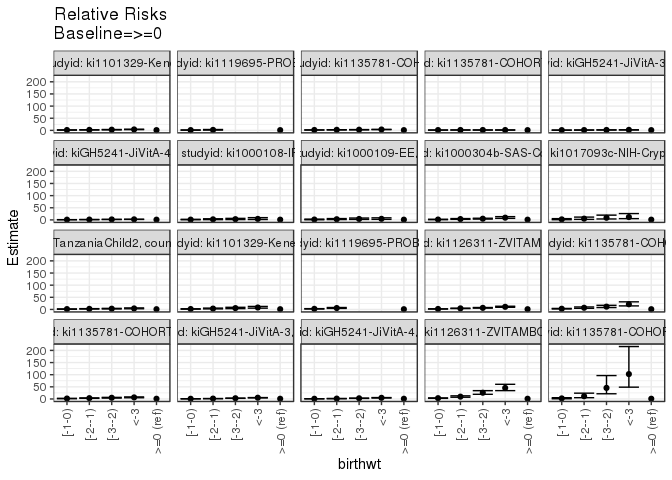

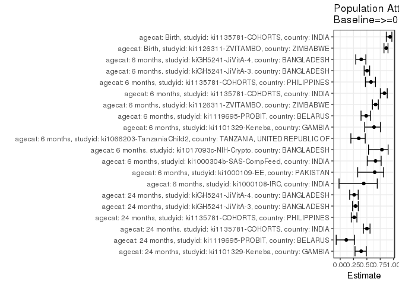

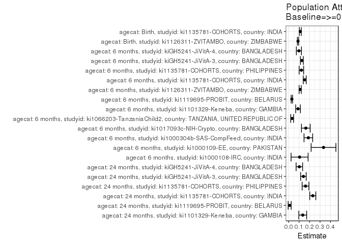

## Results Table

### Parameter: TSM

| agecat | studyid | country | intervention_level | baseline_level | estimate | ci_lower | ci_upper |
| --- | --- | --- | --- | --- | --- | --- | --- |
| Birth | ki1126311-ZVITAMBO | ZIMBABWE | >=0 | NA | 0.0141146 | 0.0102006 | 0.0180287 |
| Birth | ki1126311-ZVITAMBO | ZIMBABWE | <-3 | NA | 0.6427244 | 0.6055293 | 0.6799195 |
| Birth | ki1126311-ZVITAMBO | ZIMBABWE | [-3–2) | NA | 0.3634382 | 0.3386397 | 0.3882368 |
| Birth | ki1126311-ZVITAMBO | ZIMBABWE | [-2–1) | NA | 0.1358449 | 0.1246115 | 0.1470783 |
| Birth | ki1126311-ZVITAMBO | ZIMBABWE | [-1-0) | NA | 0.0469651 | 0.0415679 | 0.0523623 |
| Birth | ki1135781-COHORTS | INDIA | >=0 | NA | 0.0077435 | 0.0019857 | 0.0135012 |
| Birth | ki1135781-COHORTS | INDIA | <-3 | NA | 0.7936007 | 0.7557672 | 0.8314342 |
| Birth | ki1135781-COHORTS | INDIA | [-3–2) | NA | 0.3530609 | 0.3231307 | 0.3829910 |
| Birth | ki1135781-COHORTS | INDIA | [-2–1) | NA | 0.0873779 | 0.0759456 | 0.0988103 |
| Birth | ki1135781-COHORTS | INDIA | [-1-0) | NA | 0.0184640 | 0.0133040 | 0.0236240 |
| 6 months | ki1000108-IRC | INDIA | >=0 | NA | 0.1323315 | 0.0482583 | 0.2164046 |
| 6 months | ki1000108-IRC | INDIA | <-3 | NA | 0.5517677 | 0.2843520 | 0.8191834 |
| 6 months | ki1000108-IRC | INDIA | [-3–2) | NA | 0.4030530 | 0.2590219 | 0.5470840 |
| 6 months | ki1000108-IRC | INDIA | [-2–1) | NA | 0.3097419 | 0.2320048 | 0.3874790 |
| 6 months | ki1000108-IRC | INDIA | [-1-0) | NA | 0.1550336 | 0.0987061 | 0.2113610 |
| 6 months | ki1000109-EE | PAKISTAN | >=0 | NA | 0.1818704 | 0.0618437 | 0.3018970 |
| 6 months | ki1000109-EE | PAKISTAN | <-3 | NA | 0.7992020 | 0.7014795 | 0.8969244 |
| 6 months | ki1000109-EE | PAKISTAN | [-3–2) | NA | 0.7050749 | 0.6074237 | 0.8027262 |
| 6 months | ki1000109-EE | PAKISTAN | [-2–1) | NA | 0.5077054 | 0.4220864 | 0.5933245 |
| 6 months | ki1000109-EE | PAKISTAN | [-1-0) | NA | 0.2884533 | 0.2072323 | 0.3696743 |
| 6 months | ki1000304b-SAS-CompFeed | INDIA | >=0 | NA | 0.0961363 | 0.0610740 | 0.1311986 |
| 6 months | ki1000304b-SAS-CompFeed | INDIA | <-3 | NA | 0.8845624 | 0.8412823 | 0.9278425 |
| 6 months | ki1000304b-SAS-CompFeed | INDIA | [-3–2) | NA | 0.4713541 | 0.4436580 | 0.4990501 |
| 6 months | ki1000304b-SAS-CompFeed | INDIA | [-2–1) | NA | 0.3296113 | 0.2885302 | 0.3706924 |
| 6 months | ki1000304b-SAS-CompFeed | INDIA | [-1-0) | NA | 0.1467292 | 0.1102478 | 0.1832106 |
| 6 months | ki1017093c-NIH-Crypto | BANGLADESH | >=0 | NA | 0.0457312 | 0.0099510 | 0.0815114 |
| 6 months | ki1017093c-NIH-Crypto | BANGLADESH | <-3 | NA | 0.5360640 | 0.4422134 | 0.6299146 |
| 6 months | ki1017093c-NIH-Crypto | BANGLADESH | [-3–2) | NA | 0.4026544 | 0.3264482 | 0.4788607 |
| 6 months | ki1017093c-NIH-Crypto | BANGLADESH | [-2–1) | NA | 0.2366229 | 0.1902212 | 0.2830246 |
| 6 months | ki1017093c-NIH-Crypto | BANGLADESH | [-1-0) | NA | 0.1003875 | 0.0640270 | 0.1367481 |

[output cut: 66 more lines]

### Parameter: E(Y)

| agecat | studyid | country | intervention_level | baseline_level | estimate | ci_lower | ci_upper |
| --- | --- | --- | --- | --- | --- | --- | --- |
| Birth | ki1126311-ZVITAMBO | ZIMBABWE | NA | NA | 0.1035430 | 0.0984652 | 0.1086208 |
| Birth | ki1135781-COHORTS | INDIA | NA | NA | 0.1191804 | 0.1113849 | 0.1269758 |
| 6 months | ki1000108-IRC | INDIA | NA | NA | 0.2369077 | 0.1952403 | 0.2785751 |
| 6 months | ki1000109-EE | PAKISTAN | NA | NA | 0.5149051 | 0.4638428 | 0.5659675 |
| 6 months | ki1000304b-SAS-CompFeed | INDIA | NA | NA | 0.2843137 | 0.2660295 | 0.3025980 |
| 6 months | ki1017093c-NIH-Crypto | BANGLADESH | NA | NA | 0.2097902 | 0.1799252 | 0.2396552 |
| 6 months | ki1066203-TanzaniaChild2 | TANZANIA, UNITED REPUBLIC OF | NA | NA | 0.0965174 | 0.0836046 | 0.1094302 |
| 6 months | ki1101329-Keneba | GAMBIA | NA | NA | 0.1415313 | 0.1250727 | 0.1579900 |
| 6 months | ki1119695-PROBIT | BELARUS | NA | NA | 0.0626864 | 0.0488489 | 0.0765238 |
| 6 months | ki1126311-ZVITAMBO | ZIMBABWE | NA | NA | 0.1660012 | 0.1579791 | 0.1740234 |
| 6 months | ki1135781-COHORTS | INDIA | NA | NA | 0.1852739 | 0.1756495 | 0.1948983 |
| 6 months | ki1135781-COHORTS | PHILIPPINES | NA | NA | 0.2102102 | 0.1947347 | 0.2256857 |
| 6 months | kiGH5241-JiVitA-3 | BANGLADESH | NA | NA | 0.2511506 | 0.2430432 | 0.2592580 |
| 6 months | kiGH5241-JiVitA-4 | BANGLADESH | NA | NA | 0.2488856 | 0.2327574 | 0.2650138 |
| 24 months | ki1101329-Keneba | GAMBIA | NA | NA | 0.3428571 | 0.3182897 | 0.3674246 |
| 24 months | ki1119695-PROBIT | BELARUS | NA | NA | 0.0852540 | 0.0554439 | 0.1150642 |
| 24 months | ki1135781-COHORTS | INDIA | NA | NA | 0.4603991 | 0.4463860 | 0.4744122 |
| 24 months | ki1135781-COHORTS | PHILIPPINES | NA | NA | 0.6152246 | 0.5957714 | 0.6346779 |
| 24 months | kiGH5241-JiVitA-3 | BANGLADESH | NA | NA | 0.4909070 | 0.4777319 | 0.5040821 |
| 24 months | kiGH5241-JiVitA-4 | BANGLADESH | NA | NA | 0.3905665 | 0.3719151 | 0.4092179 |

### Parameter: RR

| agecat | studyid | country | intervention_level | baseline_level | estimate | ci_lower | ci_upper |
| --- | --- | --- | --- | --- | --- | --- | --- |
| Birth | ki1126311-ZVITAMBO | ZIMBABWE | >=0 | >=0 | 1.0000000 | 1.0000000 | 1.000000 |
| Birth | ki1126311-ZVITAMBO | ZIMBABWE | <-3 | >=0 | 45.5361006 | 34.3030796 | 60.447531 |
| Birth | ki1126311-ZVITAMBO | ZIMBABWE | [-3–2) | >=0 | 25.7490770 | 19.3530261 | 34.258982 |
| Birth | ki1126311-ZVITAMBO | ZIMBABWE | [-2–1) | >=0 | 9.6244165 | 7.2063969 | 12.853774 |
| Birth | ki1126311-ZVITAMBO | ZIMBABWE | [-1-0) | >=0 | 3.3274086 | 2.4647051 | 4.492078 |
| Birth | ki1135781-COHORTS | INDIA | >=0 | >=0 | 1.0000000 | 1.0000000 | 1.000000 |
| Birth | ki1135781-COHORTS | INDIA | <-3 | >=0 | 102.4867027 | 48.6498555 | 215.900420 |
| Birth | ki1135781-COHORTS | INDIA | [-3–2) | >=0 | 45.5947760 | 21.5727998 | 96.365962 |
| Birth | ki1135781-COHORTS | INDIA | [-2–1) | >=0 | 11.2841092 | 5.3038541 | 24.007282 |
| Birth | ki1135781-COHORTS | INDIA | [-1-0) | >=0 | 2.3844636 | 1.0775191 | 5.276627 |
| 6 months | ki1000108-IRC | INDIA | >=0 | >=0 | 1.0000000 | 1.0000000 | 1.000000 |
| 6 months | ki1000108-IRC | INDIA | <-3 | >=0 | 4.1695889 | 1.8756640 | 9.268969 |
| 6 months | ki1000108-IRC | INDIA | [-3–2) | >=0 | 3.0457836 | 1.4693710 | 6.313448 |
| 6 months | ki1000108-IRC | INDIA | [-2–1) | >=0 | 2.3406522 | 1.1821584 | 4.634449 |
| 6 months | ki1000108-IRC | INDIA | [-1-0) | >=0 | 1.1715551 | 0.5636107 | 2.435265 |
| 6 months | ki1000109-EE | PAKISTAN | >=0 | >=0 | 1.0000000 | 1.0000000 | 1.000000 |
| 6 months | ki1000109-EE | PAKISTAN | <-3 | >=0 | 4.3943497 | 2.2447753 | 8.602335 |
| 6 months | ki1000109-EE | PAKISTAN | [-3–2) | >=0 | 3.8767994 | 1.9759488 | 7.606256 |
| 6 months | ki1000109-EE | PAKISTAN | [-2–1) | >=0 | 2.7915787 | 1.4123266 | 5.517783 |
| 6 months | ki1000109-EE | PAKISTAN | [-1-0) | >=0 | 1.5860380 | 0.7741288 | 3.249481 |
| 6 months | ki1000304b-SAS-CompFeed | INDIA | >=0 | >=0 | 1.0000000 | 1.0000000 | 1.000000 |
| 6 months | ki1000304b-SAS-CompFeed | INDIA | <-3 | >=0 | 9.2011297 | 6.3418659 | 13.349508 |
| 6 months | ki1000304b-SAS-CompFeed | INDIA | [-3–2) | >=0 | 4.9029778 | 3.5031829 | 6.862100 |
| 6 months | ki1000304b-SAS-CompFeed | INDIA | [-2–1) | >=0 | 3.4285835 | 2.1873829 | 5.374086 |
| 6 months | ki1000304b-SAS-CompFeed | INDIA | [-1-0) | >=0 | 1.5262626 | 0.8748329 | 2.662769 |
| 6 months | ki1017093c-NIH-Crypto | BANGLADESH | >=0 | >=0 | 1.0000000 | 1.0000000 | 1.000000 |
| 6 months | ki1017093c-NIH-Crypto | BANGLADESH | <-3 | >=0 | 11.7220629 | 5.2601711 | 26.122108 |
| 6 months | ki1017093c-NIH-Crypto | BANGLADESH | [-3–2) | >=0 | 8.8048076 | 3.9383500 | 19.684547 |
| 6 months | ki1017093c-NIH-Crypto | BANGLADESH | [-2–1) | >=0 | 5.1742110 | 2.3115078 | 11.582249 |
| 6 months | ki1017093c-NIH-Crypto | BANGLADESH | [-1-0) | >=0 | 2.1951653 | 0.9278737 | 5.193326 |

[output cut: 66 more lines]

### Parameter: PAR

| agecat | studyid | country | intervention_level | baseline_level | estimate | ci_lower | ci_upper |
| --- | --- | --- | --- | --- | --- | --- | --- |
| Birth | ki1126311-ZVITAMBO | ZIMBABWE | >=0 | NA | 0.0894284 | 0.0836039 | 0.0952530 |
| Birth | ki1135781-COHORTS | INDIA | >=0 | NA | 0.1114369 | 0.1021807 | 0.1206932 |
| 6 months | ki1000108-IRC | INDIA | >=0 | NA | 0.1045763 | 0.0232272 | 0.1859253 |
| 6 months | ki1000109-EE | PAKISTAN | >=0 | NA | 0.3330348 | 0.2148450 | 0.4512246 |
| 6 months | ki1000304b-SAS-CompFeed | INDIA | >=0 | NA | 0.1881774 | 0.1468555 | 0.2294994 |
| 6 months | ki1017093c-NIH-Crypto | BANGLADESH | >=0 | NA | 0.1640590 | 0.1223994 | 0.2057186 |
| 6 months | ki1066203-TanzaniaChild2 | TANZANIA, UNITED REPUBLIC OF | >=0 | NA | 0.0336206 | 0.0200311 | 0.0472102 |
| 6 months | ki1101329-Keneba | GAMBIA | >=0 | NA | 0.0898217 | 0.0671967 | 0.1124467 |
| 6 months | ki1119695-PROBIT | BELARUS | >=0 | NA | 0.0305379 | 0.0242602 | 0.0368155 |
| 6 months | ki1126311-ZVITAMBO | ZIMBABWE | >=0 | NA | 0.1102297 | 0.0997739 | 0.1206855 |
| 6 months | ki1135781-COHORTS | INDIA | >=0 | NA | 0.1535491 | 0.1394681 | 0.1676301 |
| 6 months | ki1135781-COHORTS | PHILIPPINES | >=0 | NA | 0.1214284 | 0.0999883 | 0.1428684 |
| 6 months | kiGH5241-JiVitA-3 | BANGLADESH | >=0 | NA | 0.1264004 | 0.1129196 | 0.1398811 |
| 6 months | kiGH5241-JiVitA-4 | BANGLADESH | >=0 | NA | 0.0979809 | 0.0737127 | 0.1222491 |
| 24 months | ki1101329-Keneba | GAMBIA | >=0 | NA | 0.1347102 | 0.0974049 | 0.1720155 |
| 24 months | ki1119695-PROBIT | BELARUS | >=0 | NA | 0.0097085 | -0.0045251 | 0.0239421 |
| 24 months | ki1135781-COHORTS | INDIA | >=0 | NA | 0.2304797 | 0.2016363 | 0.2593231 |
| 24 months | ki1135781-COHORTS | PHILIPPINES | >=0 | NA | 0.1612321 | 0.1288495 | 0.1936147 |
| 24 months | kiGH5241-JiVitA-3 | BANGLADESH | >=0 | NA | 0.1410336 | 0.1145572 | 0.1675099 |
| 24 months | kiGH5241-JiVitA-4 | BANGLADESH | >=0 | NA | 0.1022332 | 0.0712249 | 0.1332415 |

### Parameter: PAF

| agecat | studyid | country | intervention_level | baseline_level | estimate | ci_lower | ci_upper |
| --- | --- | --- | --- | --- | --- | --- | --- |
| Birth | ki1126311-ZVITAMBO | ZIMBABWE | >=0 | NA | 0.8636836 | 0.8209392 | 0.8962243 |
| Birth | ki1135781-COHORTS | INDIA | >=0 | NA | 0.9350275 | 0.8637636 | 0.9690139 |
| 6 months | ki1000108-IRC | INDIA | >=0 | NA | 0.4414220 | -0.0218741 | 0.6946694 |
| 6 months | ki1000109-EE | PAKISTAN | >=0 | NA | 0.6467886 | 0.3284353 | 0.8142275 |
| 6 months | ki1000304b-SAS-CompFeed | INDIA | >=0 | NA | 0.6618655 | 0.5068458 | 0.7681558 |
| 6 months | ki1017093c-NIH-Crypto | BANGLADESH | >=0 | NA | 0.7820146 | 0.5310349 | 0.8986755 |
| 6 months | ki1066203-TanzaniaChild2 | TANZANIA, UNITED REPUBLIC OF | >=0 | NA | 0.3483375 | 0.2001945 | 0.4690410 |
| 6 months | ki1101329-Keneba | GAMBIA | >=0 | NA | 0.6346417 | 0.4591175 | 0.7532058 |
| 6 months | ki1119695-PROBIT | BELARUS | >=0 | NA | 0.4871530 | 0.3905770 | 0.5684244 |
| 6 months | ki1126311-ZVITAMBO | ZIMBABWE | >=0 | NA | 0.6640295 | 0.6043328 | 0.7147194 |
| 6 months | ki1135781-COHORTS | INDIA | >=0 | NA | 0.8287680 | 0.7521224 | 0.8817143 |
| 6 months | ki1135781-COHORTS | PHILIPPINES | >=0 | NA | 0.5776521 | 0.4726246 | 0.6617632 |
| 6 months | kiGH5241-JiVitA-3 | BANGLADESH | >=0 | NA | 0.5032852 | 0.4488657 | 0.5523312 |
| 6 months | kiGH5241-JiVitA-4 | BANGLADESH | >=0 | NA | 0.3936784 | 0.2916263 | 0.4810284 |
| 24 months | ki1101329-Keneba | GAMBIA | >=0 | NA | 0.3929048 | 0.2778143 | 0.4896539 |
| 24 months | ki1119695-PROBIT | BELARUS | >=0 | NA | 0.1138777 | -0.0752341 | 0.2697286 |
| 24 months | ki1135781-COHORTS | INDIA | >=0 | NA | 0.5006084 | 0.4345452 | 0.5589534 |
| 24 months | ki1135781-COHORTS | PHILIPPINES | >=0 | NA | 0.2620703 | 0.2070745 | 0.3132517 |
| 24 months | kiGH5241-JiVitA-3 | BANGLADESH | >=0 | NA | 0.2872918 | 0.2316883 | 0.3388713 |
| 24 months | kiGH5241-JiVitA-4 | BANGLADESH | >=0 | NA | 0.2617562 | 0.1774827 | 0.3373952 |